# Avancées et reculs des démocraties

Auteur·rice

Skarbimir Prokopek

## 1 L’horizon démocratique

Au lendemain de la Seconde Guerre mondiale, la démocratie (dans sa variante représentative et libérale) s’impose dans l’Europe libérée de l’occupation allemande. La victoire de 1945 ouvre une troisième (après le Congrès de Vienne de 1814-1815 et la série des traités concluant la Première guerre mondiale en 1918-1919) tentative de construire de manière réfléchie un ordre mondial destiné à garantir une paix durable. La démocratie libérale est alors envisagée comme un horizon: c’est le régime appelé à se diffuser, d’abord en Europe, dans le monde ensuite.

Cette diffusion est tributaire de réflexions théoriques plus anciennes, comme la pensée des théoriciens de la démocratie qu’on a étudié dans le précédent chapitre, mais aussi des débats beaucoup plus récents. Les deux ne sont pas déconnectés.

### 1.1 Les réflexions autour de la démocratie

Les réflexions modernes sur la démocratie (rappelez-vous de la liste de citations dont nous nous sommes servi pour l’activité introductive) sont très souvent méfiantes. Les deux dangers soulignés par Alexis de Tocqueville, la **tyrannie de la majorité**, qui aboutit à l’écrasement des minorités par la majorité, et surtout le **despotisme démocratique**, qui est la tendance au recul dans la sphère privée et l’indifférence à l’égard de la politique. La première de ces critiques peut être reliée à ce qui est aujourd’hui désigné comme les régimes **populistes**, c’est-à-dire les régimes qui font appel au peuple dans leur rhétorique et s’appuient sur le sentiment majoritaire, ou supposé tel, pour justifier une pratique politique autoritaire. Dans une histoire plus large du débat sur la démocratie, la crainte de la «tyrannie de la majorité» rejoint la méfiance, exprimée dès l’Antiquité, du peuple perçu comme une foule désordonnée et violente.

Le «despotisme démocratique», critique plus complexe, est moins mobilisée lors de l’organisation des démocraties européennes après la Seconde Guerre mondiale. Elle rejoint bien davantage les mouvements de protestation récents, tels que les Gilets jaunes en France ou les mouvements d’occupation des places dans plusieurs pays occidentaux au début des années 2010. Au contraire, la construction démocratique d’après-guerre répond à un autre axe de critique de la démocratie, qui a été très présent dans les débats d’avant-guerre. La démocratie a alors été fréquemment dénoncée comme un régime inefficace, bavard, incapable d’agir efficacement et rapidement. En France, cette critique est portée par le milieu des **non-conformistes** des années 1930 qui critiquent la III<sup>e</sup> République (1870-1940) et appellent à une réforme institutionnelle qui renforcerait le pouvoir exécutif. Ces réflexions animent la construction des institutions de la V<sup>e</sup> république actuelle.

Les débats actuels autour de la démocratie (telle qu’elle existe en Occident) se focalisent plutôt sur la **représentation**: les mouvements de contestation récents soulignent l’écart qui existe entre les gouvernants et les gouvernés, ainsi que l’indifférence des démocraties représentatives à l’augmentation des inégalités sociales.

### 1.2 Le processus de démocratisation

Rappelons la chronologie générale que nous avons déjà signalée dans le précédent chapitre.  
La **fin de la Seconde Guerre mondiale** lance une première vague de démocratisation, qui tranche avec la situation de l’Europe d’avant-guerre. À la fin du xix<sup>e</sup>, comme dans la période d’entre-deux-guerres, les démocraties sont une **exception plutôt que la règle** sur le continent européen: seules la Grande-Bretagne et la France sont démocratiques (nous mettons pour le moment de côté toutes les réserves que l’on peut exprimer à propos de la démocratie dans ces deux pays); on peut ajouter la Suisse neutre. Les expériences démocratiques des années 1920 tournent en général à l’échec, sauf pour la Tchécoslovaquie.  
Dans l’immédiat après-guerre, la démocratie représentative libérale s’impose dans toute l’Europe occidentale, à l’exception des dictatures conservatrices en Espagne et au Portugal, qui arrivent à s’adapter à la nouvelle réalité et se maintenir. Dans le contexte de la Guerre froide, la démocratie libérale tire des conclusions du passé du danger fasciste, mais se construit surtout contre l’adversaire soviétique; de son côté, l’Union soviétique installe en Europe de l’Est des régimes de *démocratie populaire*, qui tirent une inspiration du marxisme, mais varient très fortement entre eux.

Les années 1970 marquent une nouvelle étape dans la démocratisation du monde. En Europe, plusieurs dictatures conservatrices, qui bénéficiaient de l’anticommunisme de la guerre froide, tombent pour être remplacées par des démocraties: c’est le cas du Portugal (1974), de l’Espagne (à partir de la mort du dictateur Franco en 1975), mais aussi de la Grèce (1974).  
Le processus de **décolonisation** permet à plusieurs pays colonisés d’accéder à l’indépendance; les institutions démocratiques sont largement adoptées, mais la situation internationale (maintien de la domination des anciennes puissances à travers le **néocolonialisme**, rivalité de Guerre froide par factions interposées…) les rend souvent fragiles.

La chute de l’Union soviétique permet une vague massive de démocratisation: les anciennes démocraties populaires, ainsi que les pays qui avaient fait partie de l’URSS et qui ont proclamé leur indépendance, s’alignent sur le modèle de la démocratie libérale, vue comme un horizon universel.

Cet optimisme, qui a caractérisé les années 1990, voire le début des années 2000, s’est essoufflé plus récemment. Le mouvement appelé (en Occident) le **Printemps arabe**, entre 2010 et 2012, a abouti à un processus de transformation politique en Tunisie, mais a été écrasé dans le Golfe arabo-persique, en Egypte un régime autoritaire s’est installé après la chute du président Mubarak, et en Syrie et en Libye, des guerres civiles prolongées ont suivi le mouvement. Simultanément, des critiques de plus en plus tranchées émergeaient dans les pays de démocratie ancienne (Manifestations très durement réprimées contre le sommet G8 à **Gênes en 2001**, *Occupy Wall Street* aux USA, plusieurs mouvements de protestation en France, l’occupation de la Puerta del Sol à Madrid). Dans les démocraties d’Europe de l’Est, qualifiées de *jeunes*, l’enthousiasme retombe, tandis que le creusement des inégalités transforme une quantité importante de perdants de la transformation libérale en électeurs potentiels des mouvements anti- ou simplement non-démocratiques. Ainsi, les succès de l’extrême droite en Hongrie (avec Victor Orbàn) ou en Pologne alimentent l’inquiétude de la montée du **populisme** ou de l’**illibéralisme**.

## 2 Deux transitions démocratiques: le Portugal et l’Espagne

Les transitions démocratiques au Portugal et en Espagne fournissent un double modèle pour comprendre la deuxième phase de la démocratisation, particulièrement en Europe. L’exemple est d’autant plus intéressant que les deux pays connaissent des situation de départ très similaires, connaissent leur transition à la même époque, et aboutissent à une situation très proche: l’intégration dans l’espace politique de l’Europe occidentale démocratique, confirmée par l’entrée des deux pays dans la **CEE** (Communauté Économique Européenne, ancêtre de l’Union Européenne actuelle) en 1986. Pourtant, leur expérience est diamétralement différente, si bien que la transition espagnole se construit dans l’opposition à l’exemple portugais.

### 2.1 La Révolution des Œillets

#### 2.1.1 Le vieillissement de l’*Estado Novo*

La dictature qui prend place en 1974 est en place depuis longtemps: le témoignage d’un Portugais émigré en France, cité dans le manuel, insiste sur cette durée et sur la difficulté, pour les acteurs de l’époque, d’imaginer que la situation puisse jamais changer.  
Le régime portugais s’était installé dès 1926 (soit avec dix ans d’«avance» sur le voisin espagnol), lorsqu’un coup d’État militaire renverse la Première république portugaise. Ce premier régime, nommé la «Dictature nationale» se transforme, sans perdre le caractère autoritaire. En 1928, le général Oscar Carmona, devenu président de la République, nomme ministre des Finances le professeur d’économie politique à la faculté de droit de Coimbra, **Antonio de Oliveira Salazar**.  
Le succès de ses réformes place Salazar en position favorable. en 1932, après une crise ministérielle, il devient Premier ministre et s’entoure d’une équipe d’intellectuels conservateurs, professeurs d’économie ou de droit, à tel point que l’on parle de *cathédrocratie*. En 1933, ce groupe propose une nouvelle constitution, validée par un **plébiscite**: le projet de l’*Estado Novo* est ainsi formalisé. Il s’agit d’une politique autoritaire, animée par l’anticommunisme et l’antilibéralisme, mais rejetant aussi le modèle fasciste de l’Italie de Mussolini et de l’Allemagne nazie. Dans la doctrine sociale de l’Église catholique, le salazarisme puise le **corporatisme**, qui lui permet de combattre toute organisation syndicale et protéger le pouvoir du patronat. Le parlement est entièrement soumis à l’exécutif (le Conseil des ministres), les élections sont maintenues pour la forme mais ne servent qu’à confirmer l’unique candidat proposé.

Le régime tient à une **orthodoxie budgétaire** qui assure au pays de bons indicateurs économiques mais maintient la population dans la pauvreté – ce que Salazar juge plutôt bon, puisque la pauvreté favorise le maintien des valeurs traditionnelles.

Dès l’origine, le régime salazariste est **fortement colonialiste**: Salazar voit dans le maintien de l’empire colonial portugais la garantie d’une grandeur nationale qu’il cherche à restaurer. Dès l’arrivée de Salazar au ministère des Finances, les dépenses militaires augmentent et deviennent un poids écrasant lorsque les guerres de libération commencent en Angola et au Mozambique dans les années 1960. Bien que le régime reprend à son compte la conception du **lusotropicalisme**, selon laquelle le colonialisme portugais serait différent et meilleur que ceux pratiqués par les autres puissances coloniales. En dépit de ce discours sur la formation par la colonisation d’un grand Portugal intégrant les populations colonisées plutôt que de les dominer, la réalité est celle d’une ségrégation raciale qui se renforce; les colonies portugaises connaissent aussi un développement comparativement plus faible.

Le régime survit sans difficulté à la guerre. Malgré la proximité avec l’Italie fasciste, l’Allemagne nazie et l’Espagne franquiste voisine, Salazar maintient l’alliance historique avec la Grande-Bretagne et reste à l’écart de la guerre. La répression est réelle, mais ciblée. La PIDE, police politique, a été formée sur le modèle le l’OVRA italienne, mais Salazar trouve cette dernière trop indépendante et aligne sa police politique sur le modèle de l’MI5 britannique.  
Après la guerre, le Portugal s’intègre facilement dans le front anticommuniste de la Guerre froide, ainsi le pays fait partie des membres fondateurs de l’OTAN.

La succession, qui s’opère en 1968, donne la preuve de la stabilité du régime. Salazar, âgé, se retire après avoir subi un accident vasculaire-cérébral; il est alors remplacé par **Marcelo Caetano**.

Cette solidité n’exclut pas une usure du pouvoir. L’opposition politique n’est pas totalement absente et cause même quelques frayeurs au régime, qui supprime l’élection directe du président de la république en 1958, après qu’un candidat sérieux a pu émerger. Surtout, le régime est travaillé par l’**émigration massive**. Les Portugais quittent le pays pour chercher du travail, en dépit de l’**interdiction**. Le régime interdit l’émigration pour des raisons économiques, considérant que le pays perd ses forces vives, mais aussi militaires (les travailleurs qui partent sont autant de soldats disponibles en moins) et politiques: le contact avec des sociétés plus ouvertes, notamment en France, inquiète le pouvoir attaché aux autorités et valeurs traditionnelles. L’interdiction reste vaine, d’autant plus que la France accueille volontiers les travailleurs portugais, et que l’Espagne les laisse traverser son territoire.

Mais la cause la plus directe de la chute du salazarisme est la guerre coloniale qui absorbe jusqu’à 40% des ressources du pays et qui occasionne la perte de plus de 16 000 soldats portugais (ainsi que 20 000 combattants indépendantistes et 110 000 civils). Non seulement la guerre est impopulaire et contribue à l’émigration, mais elle est de plus en plus rejetée par les militaires eux-mêmes, conscients de l’impossibilité de maintenir les colonies portugaises. Le livre *Le Portugal et l’avenir*, publié au début de 1974 par le général **Antonio de Spinola** exprime publiquement ce sentiment, que le général de Spinola avait dès 1972 communiqué à Caetano. Ce dernier avait refusé toute solution politique.

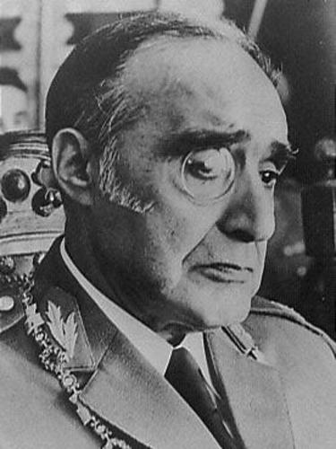

Le général Antonio de Spinola, octobre 1974

Parallèlement, des officiers subalternes forment la **Mouvement des Forces Armées** (MFA) qui formule le programme de **démocratisation, décolonisation, développement**.

#### 2.1.2 25 Avril: une révolution pacifique

Deux moments sont symboliques: la diffusion par la radio de la chanson *Grândola, Vila Morena* de Zeca Afonso donne le signal du soulèvement. L’armée, menée par les officiers du MFA, prend le contrôle de la capitale. Pour éviter les victimes, les militaires appellent la population au calme. Les habitants de Lisbonne refusent de rester chez eux et descendent dans la rue; c’est alors que les fleurs d’œillet sont distribuées aux militaires qui les portent à la boutonnière ou, de manière encore plus symbolique, insérées dans le canon de leurs fusils.

[video not shown]

Les images montrent une foule pacifique aux côtés des militaires présents en armes, mais sans violence. Seule la PIDE essaye de combattre et fait quatre morts en tirant dans la foule. Caetano, encerclé dans la caserne de la gendarmerie, négocie. Il considère le MFA comme un mouvement communiste (certains militaires du MFA le sont réellement, pas tous) et se méfie de la rue, il accepte en revanche de se retirer au profit du général de Spinola, un homme de droite. Mais ce dernier avait multiplié les contacts avec le MFA avant le coup d’État, la solution est donc acceptée. Caetano est exilé vers l’île de Madère, puis vers le Brésil, gouverné à l’époque par une junte militaire de droite.

Le pouvoir provisoire est tenu par la **Junte de salut national** composée de militaires prestigieux, dont les généraux de Spinola et **Costa Gomez**. En dépit des divergences politiques réelles, le programme de démocratisation et décolonisation, porté par le MFA, est appliqué; les élections sont annoncées pour le 25 avril 1975. Le retrour des exilés du régime marque le changement: le leader socialiste, **Mario Soares**, revient au pays le 29 avril, suivi le lendemain par le communiste (et écrivain) **Alvaro Cunhal**.

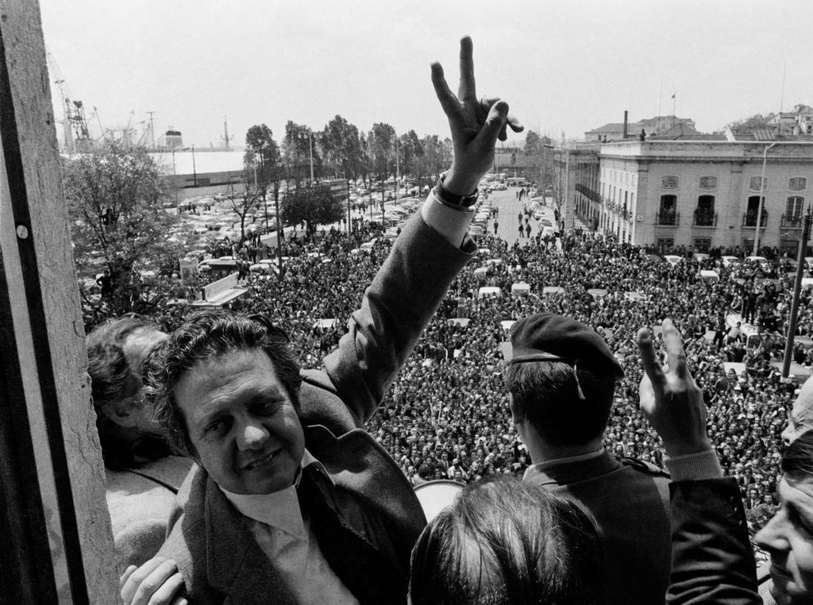

Mario Soares de retour à Lisbonne

#### 2.1.3 Du PREC à la Constitution

La révolution entre dans une phase appelée PREC: **Processus révolutionnaire en cours**. Au sein du MFA comme dans la société, s’affrontent des partisans d’une politique décidément **marxiste-léninste** et des modérés, partisans d’une démocratie représentative et de la planification d’une économie de réforme. Le général de Spinola, bien plus à droite, démissionne et est remplacé par le général Costa Gomes.  
L’opposition est particulièrement nette dans la région agricole du Alentejo, où les propriétaires terriens, inquiets de la perspective d’une **réforme agraire** (que les communistes voudraient voir sous forme d’une collectivisation, tandis que les réformistes favorisent des coopératives et des exploitations familiales), optent pour une tactique de sabotage et d’abandon des terres.  
Une effervescence révolutionnaire règne: des comités de quartier et des conseils d’usine sont formées, les immeubles et les usines abandonnées sont occupées, 220 entreprises se mettent en **autogestion**. Cela fait craindre à toutes les forces conservatrices, au Portugal comme à l’étranger, l’installation d’un régime marxiste aligné sur l’URSS, sur le modèle du *coup de Prague*. Le chef de la diplomatie américaine, **Henry Kissinger**, annonce que les États-Unis ne sauraient tolérer un tel développement. Au Portugal, le général de Spinola lui-même, pour écarter la «menace bolchevique», participe à l’organisation d’un contre-coup d’État sur la base militaire de Tancos. Le capitaine Dinis de Almeida déjoue la tentative; de Spinola est contraint, à son tour, à l’exil.

Les élections, organisées le 25 avril 1975 (et qui représentent un important problème pratique: la population portugaise n’est pas habituée au vote, peu de gens sont inscrits sur les listes électorales et la **diaspora**, très nombreuse, doit être incluse dans le vote), sont gagnées par les partis modérés, socialistes et social-démocrates, au détriment des communistes. La possibilité d’une prise de pouvoir communiste ou «coup de Prague» s’éloigne, mais pas celle d’une guerre civile: les membres maximalistes du MFA tentent de faire passer le plus possible de leur programme durant l’*été chaud* 1974. Des grèves et autres actions offensives des militants radicaux émaillent la période. Mais le PREC s’achève avec l’échec d’une tentative de coup d’État par les parachutistes proches du brigadier Otelo de Carvalho, un de principaux leaders du MFA. Le lieutenant-colonel Ramalho Eanes, futur président, évente la tentative. C’est l’échec définitif de l’orientation radicale.  
L’année suivante, la Constitution est adoptée, avec le soutien de tous les partis. La Troisième république portugaise, très influencée par la V<sup>e</sup> république française, est désormais dirigée par des civils: Ramalho Eanes est élu Président, au scrutin direct, avec plus de 61% de voix, et **Mario Soares** devient premier ministre.

La Révolution des Œillets est à juste titre célébrée au Portugal et ailleurs, mais elle n’a pas été imitée. Bien avant le référendum constitutionnel, c’est le moment de communion nationale le 25 avril 1974, où le peuple assemblé dans les rues de Lisbonne consacre la légitimité du coup militaire, qui est le grand moment démocratique de cette révolution. Le rôle de l’armée et l’esprit démocratique et marxiste porté par l’armée, particularité portugaise à l’échelle européenne, rapproche la révolution portugaise des événements du monde colonisé.  
L’enjeu se situe bien là: la transition portugaise de la dictature à la démocratie est bel et bien révolutionnaire et s’accompagne d’un effondrement, puis refondation du pouvoir. C’est une fierté incontestable pour le peuple portugais, mais une inquiétude pour les observateurs étrangers, la grande puissance conservatrice (USA), mais aussi les élites de l’Espagne voisine.

### 2.2 La transition espagnole: un modèle de transformation pacifique?

#### 2.2.1 Franco est mort

L’Espagne connaît un régime très comparable au Portugal. La dictature du général Francisco Franco est elle aussi en place depuis les années 1930; elle aussi avait été proche des régimes fasciste et nazi, et a été épargnée à la fin de la Seconde guerre mondiale grâce à sa neutralité formelle dans le conflit et une politique ambiguë. Le franquisme, comme le salazarisme, est antidémocratique, antilibéral, fanatiquement anticommuniste, catholique, proche de tous les pouvoirs traditionnels: Église, armée, famille, patronat. Du reste, Franco s’inspire ouvertement de Salazar, sans que les deux dictateurs s’apprécient personnellement.  
C’est que, entre les deux, il existe aussi des différences fondamentales. Salazar est un universitaire prudent, austère, qui vit comme un moine. Franco, militaire des troupes coloniales, est un mégalomane qui aime les grands monuments, les grandes cérémonies et le culte de la personnalité. Les deux régimes ne font pas le même usage de la **violence**: Franco procède à une répression féroce et massive.  
Le franquisme a le temps d’évoluer. À ses débuts, le régime est assez proche du fascisme (même s’il est toujours débattu si on peut le considérer comme pleinement fasciste) et revendique ouvertement la qualité de régime *totalitaire*.  
À la fin de la Seconde Guerre mondiale, l’Espagne franquiste se retrouve isolée politiquement et économiquement, et affaiblie, puisque la politique d’autosuffisance économique, souhaitée par la **Phalange**, échoue.  
Le franquisme tardif s’éloigne du fascisme pour accentuer le conservatisme traditionnel, catholique et moralisant. Une relative ouverture a lieu en économie, pilotée par des **technocrates** souvent membres de l’*Opus Dei*, mais il n’y a pour autant aucun assouplissement politique.

L’Espagne est formellement (à nouveau) une monarchie depuis 1947, mais il s’agit alors d’une monarchie sans roi dont Franco, avec le titre de *Caudillo*, guide, est le régent. C’est en 1969 que Franco, affaibli par l’âge, prépare sa succession et désigne **Juan Carlos de Bourbon** comme son successeur, avec le titre de **Prince d’Espagne**. Ce dernier jure «fidélité aux principes du *Movimiento nacional* et aux autre Lois fondamentales du royaume».

L’amiral **Luis Carrero Blanco**, hostile à la phalange et proche de l’*Opus Dei*, est l’homme fort du régime et potentiel héritier politique du dictateur. Catholique traditionaliste, il est un adversaire de la démocratie librale. En 1973, il est assassiné dans un attentat spectaculaire (nommé l’*Opération Ogre*; 75 kg de dynamite projettent sa voiture au-dessus d’un immeuble, faisant de lui le «premier astronaute espagnol») par l’organisation terroriste basque ETA.

Après la mort de Carrero Blanco, le prince Juan Carlos est le seul héritier possible. En 1974, Franco lui cède le pouvoir, avant de mourir enfin, après une très longue agonie, en novembre 1975. Juan Carlos est alors **couronné roi d’Espagne** et prend les rênes de l’État franquiste, sans le modifier d’emblée: on parle alors de **franquisme sans Franco**. Cependant, la société espagnole tolère de moins en moins l’ordre politique verrouillé. Pour illustration, pensez aux premiers films de Pedro Almodovar (dont le premier long métrage date de 1978, précédé par des courts-métrages artisanaux qui circulent dans Madrid, tournés avant même la mort de Franco).

#### 2.2.2 La transition modèle?

Ce n’est qu’au bout d’un an, pendant lequel des manifestations et des affrontements se multiplient, que le roi donne un signal clair de l’orientation démocratique par la désignation d’**Adolfo Suarez**, son homme de confiance et représentant de la ligne *aperturiste* (à l’opposé, la tendance dure du franquisme, opposée à toute ouverture, est appelée le **Bunker**) au sein du parti unique franquiste, comme président du gouvernement (premier ministre), en juillet 1976.  
Commence alors une série de réformes qui, de loi en loi, transforme le régime de manière négociée, **sans solution de continuité**.  
Les jalons principaux de cette transformation est la légalisation des partis politiques, en juillet 1976, suivie d’une première **amnistie** générale et des débuts de l’autonomie des régions, Les Cortes franquistes s’auto-dissolvent.  
L’année suivante, après plusieurs attentats terroristes, une nouvelle amnistie est votée; elle concerne désormais les actes terroristes n’ayant pas entraîné des victimes. Le principal organe de répression franquiste, le Tribunal de l’Ordre public, est dissous, après avoir arrêté le secrétaire général du Parti communiste (PCE), Santiago Carillo, qui était clandestinement rentré en Espagne. Le parti lui-même est légalisé en avril 1977, suivi par les centrales syndicales UGT (socialiste) et CCOO (communiste). Le *Movimiento Nacional* franquiste se dissout; il est remplacé en mai 1977 par l’**Union du centre démocratique**, fondée par le Premier ministre Adolfo Suarez.  
Ce parti sort largement vainqueur de l’élection de l’**Assemblée constituante**, qui se tient le mois suivant, suivi par le PSOE (parti socialiste) en deuxième position, les communistes étant loin derrière. La nouvelle Constitution est prête en octobre 1978, elle est approuvée par l’Assemblée, puis par référendum, le **6 décembre 1978**, date qui devient la fête nationale de la Constitution.

[video not shown]

Le dernier épisode se joue en février 1981. Le parti d’Adolfo Suarez avait gagné les élections consécutives à la promulgation de la nouvelle constitution, mais les partis de gauche ont fortement progressé dans les votes. Affaibli, le premier ministre finit par demissionner. C’est au moment de l’investiture de son successeur, Leopoldo Calvo-Sotelo, que les gardes civiles (gendarmes) commandés par le colonel **Antonio Tejero Molina** envahissent le parlement. La tentative de putsch s’autodétruit en réalité: le coup d’État est organisé par le général Alfonso Armada qui se rêve en De Gaulle espagnol (ce qui est relativement paradoxal dans la mesure où, en son temps, De Gaulle avait été soupçonné de vouloir être le Franco français…), voyant le danger dans le nationalisme basque et catalan, il souhaite donc un «gouvernement de concentration» qui inclurait des personnalités de droite et de gauche, et qu’il voudrait faire approuver par les députés. Son exécutant, Tjero, est perplexe, puisqu’il pensait installer un régime militaire pur et dur dans la tradition du *Caudillo*. Cependant, c’est l’intervention télévisée du roi Juan Carlos, ferme et convaincante, qui marque les mémoires et consolide la position de la monarchie, tout en achevant de discréditer l’armée.

#### 2.2.3 Transition inachevée?

La transition démocratique espagnole a été immédiatement saluée comme un modèle à suivre; la référence à l’Espagne a été en particulier largement mobilisée lors de la démocratisation du Chili, ou encore en Europe de l’Est après la chute de l’URSS. Or, comme le [montre l’historienne Sophie Baby](https://www.nonfiction.fr/article-10521-mythes-et-realites-de-la-transition-democratique-en-espagne.htm), ce modèle a, d’une part, de nombreuses tâches aveugles, d’autre part, la transition peut être considérée comme inachevée.

Reprenons les caractéristiques-clés de la transition espagnole:

- la **réforme graduelle**, qui se produit de loi en loi, sans rupture avec le régime antérieur ni épuration;
- la **négociation** entre les élites de l’ancien régime et les secteurs de l’opposition (on parle de la transition **pactée** et **imposée d’en haut**);
- le **consensus**, puisque les choix sont négociés et adoptés par la classe politique, puis validés massivement par la population;
- la **modération globale des comportements**, qui permet de vanter la maturité et le sens de responsabilité de la société;
- la **volonté de réconciliation**, symbolisée par la loi d’amnistie mutuelle de 1977.

Or, le caractère pacifique de cette transition doit être interrogé. Elle est pilotée par des acteurs politiques obnubilés par le **maintien de l’ordre public** et hantés par le souvenir de la guerre civile dont il s’agit à tout prix d’éviter la reprise. L’exemple portugais, s’il insipire la population dans l’aspiration à la démocratie, est perçu comme un **anti-modèle**: la révolution fait peur. Mais si le conflit est **éludé**, la violence n’est pas absente. Les attentats sont nombreux, aussi bien de la part des Basques de l’ETA ou des indépendantistes catalans, que des groupes conservateurs voire néofascistes. S. Baby souligne que les sept années de transition espagnole connaissent **710 morts, soit plus de morts par an que les «Années de plomb» en Italie contemporaine**! Par conséquent, la modération et le pacifisme de cette transition a pour objectif non pas tant d’écarter la violence que d’éviter la solution de continuité des institutions et maintenir l’ordre public: à l’opposé de la révolution portugaise, qui a réellement évité la violence mais emporté le pouvoir, l’Espagne tient surtout à maintenir le pouvoir, au prix d’une violence réelle mais euphémisée.

Au sein de l’État, en absence d’une épuration, une culture autoritaire et les opinons proches du franquisme restent très présentes au sein de la police, de la garde civile ou encore de l’armée. Cependant, la violence est **efficacement contenue** par l’État, et les actes violents ne conduisent pas à une réaction en chaîne, redoutée, mais à une unité de la société contre les groupes violents.

Cependant, la transition espagnole a pu être critiquée plus récemment comme inachevée. La double amnistie, celle des antifranquistes persécutés par la dictature comme celle des criminels au service du régime, devait former un **pacte de l’oubli**, qui n’a pas réellement eu lieu. Si des historien.ne.s se sont précipité.e.s sur les archives, et des charniers datant de la dictature franquiste sont découverts en nombre (environ 3000 fosses communes et 114 000 corps), il n’y a pas de véritable **travail de mémoire**, ni de condamnation du franquisme, à l’image de celui dont le régime nazi fait objet en Allemagne. Par conséquent, l’extrême-droite nostalgique de la dictature a pu maintenir son récit, sa mémoire voire ses fêtes: le 20 novembre, jour anniversaire de sa mort, les militants de l’extrême droite continuent à rendre hommage à Franco à la basilique de Valle de los Caidos.

[figure not shown]

Valle de los Caidos, mausolée construit à partir de 1940 pour commémorer les combattants nationalistes de la guerre civile espagnole

L’exhumation du corps du dictateur et son transfert du mausolée de Valle de los Caidos vers une sépulture plus discrète dans le cimetière de Prado, qui finit par avoir lieu en 2019, a ainsi rencontré de très fortes oppositions politiques et a été l’objet d’un long conflit.  
En 2020 éclate l’affaire du «Chat des 26 millions». Un groupe de hauts gradés retraités de l’armée adressent au roi Felipe VI une lettre ouverte dans laquelle ils accusent le Premier ministre socialiste Pedro Sanchez et Pablo Iglesias (du mouvement de gauche Unidos Podemos) de trahison et appellent à une intervention des forces armées. Peu de temps après, le site *Infolibre* révèle l’existence d’une groupe WhatsApp dans lequel plusieurs militaires à la retraite échangeaient des appels à renverser le gouvernement, faisaient l’éloge du franquisme et évoquaient une éventuelle «opération Albatros», sans qu’un projet concret de coup d’État ait été formé. Dans l’esprit très proche du franquisme des débuts, ils parlaient de fusiller 26 millions d’Espagnols.

Ainsi, le Portugal et l’Espagne, aux parcours très parallèles, donnent l’exemple de deux manières très différentes de sortir des régimes autoritaires: la révolution portugaise, réellement pacifique, fait passer le pays par une rupture franche avec le passé, là où la transition espagnole s’efforce d’éviter les ruptures au prix d’une forme d’inachèvement.

## 3 Le Chili: l’échec et le retour d’un projet démocratique

L’histoire du Chili résume, dans un seul pays, ce balancement entre une démocratisation révolutionnaire, la réaction autoritaire et une démocratisation progressive.

### 3.1 Le «chemin de crête» de Salvador Allende: une révolution démocratique par l’État (1970-1973)

La tentative menée par l’**Unité populaire** au Chili est un projet révolutionnaire de conquête de la démocratie par les institutions de l’État. Cette volonté de concilier l’ambition révolutionnaire et un respect de la légalité, à distance d’un modèle soviétique de la révolution armée, constitue l’originalité et, potentiellement, la fragilité de de ce projet.

La victoire électorale de l’Union populaire est l’aboutissement d’un long processus politique, la stratégie institutionnelle de l’alliance politique entre les communistes, les socialistes et les chrétiens de gauche est poursuivie depuis les années 1950. En 1970 s’ouvre une fenêtre de possibilité après l’échec d’un gouvernement démocrate-chrétien (1964-1970), soutenu par les États-Unis. **Salvador Allende** est un homme politique expérimenté; il a été déjà trois fois candidat, il est cofondateur du PS, franc-maçon, ancien ministre et président du Sénat. Tout en étant un connaisseur des institutions, il se réclame ouvertement de Marx et admire Fidel Castro, mais défend une possibilité de révolution non-violente et légaliste.

Ce légalisme lui est d’autant plus indispensable que son avance électorale est assez faible: au terme d’une campagne dynamique, il obtient 36.6% des votes, à peine devant le candidat de la droite conservatrice Jorge Alessandri (35.2%), le candidat de la démocratie chrétienne (DC), Rodomiro Tomic, est troisième avec 28% de votes. Allende doit donc donner des garanties de stabilité à la DC pour s’assurer leur soutien.

Le gouvernement se lance dans une série de réformes immédiates, qui nécessitent souvent des moyens qualifiés de «guérilla juridique» pour faire passer des lois au Parlement, ou passer par des décrets-lois présidentiels. Les mesures visent l’**augmentation des salaires**, l’approfondissement de la **réforme agraire**, ou encore la **nationalisation des entreprises**. Les entreprises nationalisées ou saisies sous la pression des travailleurs (cas de 260 entreprises sur plus de 400) forment une Aire de propriété sociale (APS). Une planification économique, qui fait un usage très novateur des ordinateurs, est mise en place.

[video not shown]

Une de plus grandes victoires politiques est la nationalisation-expropriation du **cuivre**, principale richesse minérale du pays, obtenue à l’unanimité du Congrès (après la réforme constitutionnelle) et 1971; Mais c’est aussi un défi direct à la domination des États-Unis. Allende apparaît ainsi comme un champion du **tiers-monde non-aligné**, mais les États-Unis du président Nixon craignent un rapprochement avec le Cuba révolutionnaire et une contagion dans le continent qu’ils voient comme leur pré carré. L’ambassade étasunienne à Santiago, la CIA, le Pentagone et les multinationales présentes sur place se coordonnent pour freiner Allende par tous les moyens.

Le pays est en état d’effervescence, des grèves et occupations d’usines se multiplient de manière spontanée, sans attendre les consignes des partis ou syndicats. Sur le plan électoral, la stratégie offensive est payante: l’UP obtient près de 50% dans les élections municipales de 1971. Mais Allende renonce à profiter de l’occasion pour dissoudre le Congrès, appeler les nouvelles élections et lancer un référendum constitutionnel.

### 3.2 La mort d’une démocratie: le coup d’État du général Pinochet

Le projet révolutionnaire porté par l’Union populaire suscite une très forte opposition de toutes les forces conservatrices du pays. L’appareil productif n’arrive pas à suivre la hausse de la demande intérieure. Dans le pays dépendant de l’extérieur, cela se traduit par une forte inflation et des pénuries. Elle est aggravée par l’hostilité des banques et des institutions économiques internationales qui souhaitent voir Allende échouer. Les médias conservateurs, notamment le journal *El Mercurio*, préparent les esprits en diffusant des images de chaos qui entretiennent la peur dans la petite-bourgeoisie. Dans le champ politique, la Démocratie chrétienne abandonne l’Unité populaire et bascule vers la position putschiste.  
Dans la rue, pendant que des groupes d’extrême-droite comme *Patria y Libertad* multiplient des attentats, des contre-manifestations conservatrices sont organisées: la «marche des casseroles vides», qui rassemble des femmes de droite, mobilise le thème de la famille.  
Reprenant la stratégie des adversaires, la grève des camionneurs et transporteurs, soutenue par la CIA et les organisations patronales, contribue à paralyser l’économie du pays.  
La stratégie révolutionnaire mais légaliste d’Allende se trouve alors dans une impasse. Face à l’action de plus en plus violente des conservateurs, des formes d’organisation spontanées (auto-organisation populaire; «cordons industriels» autour des usines…) émergent mais manquent de coordination et surtout, ne sont pas directement soutenues par le gouvernement: ce serait, en effet, le basculement vers une voie ouvertement révolutionnaire.  
En parallèle, la place des militaires au sein des institutions se renforce; le général Prats est nommé ministre de l’Intérieur (1972), puis de la Défense. Allende fait le pari du «constitutionnalisme», c’est-à-dire allégeance à l’ordre institutionnel, de l’armée. C’est Allende lui-même qui nomme chef de l’État-major le général Augusto Pinochet, réputé «légaliste».

Mais le **11 septembre 1973**, ce général est à la tête du soulèvement des forces armées qui bénéficie de l’appui explicite de l’administration Nixon. La gauche se retrouve désarmée, enterrant l’espoir de faire du Chili un «deuxième Vietnam».

Salvador Allende refuse de se rendre. Depuis le palais présidentiel, il prononce un dernier discours transmis par la radio, puis se suicide. La dictature militaire s’impose dans le pays.

> Je paierai de ma vie la défense des principes qui sont chers à cette patrie. La honte tombera sur ceux qui ont trahi leurs convictions, manqué à leur propre parole et se sont tournés vers la doctrine des forces armées. Le peuple doit être vigilant, il ne doit pas se laisser provoquer, ni massacrer mais il doit défendre ses acquis. Il doit défendre le droit de construire avec son propre travail une vie digne et meilleure. A propos de ceux qui ont soi-disant «autoproclamé» la démocratie, ils ont incité la révolte, et ont d’une façon insensée et louche mener le Chili dans le gouffre. Au nom des plus gros intérêts du peuple, au nom de la patrie, je vous appelle pour vous dire de garder l’espoir. l’Histoire ne s’arrête pas ni avec la répression, ni avec le crime. C’est une étape à franchir, un moment difficile. Il est possible qu’ils nous écrasent mais l’avenir appartiendra au peuple, aux travailleurs. L’humanité avance vers la conquête d’une vie meilleure.

> Compatriotes, il nous est possible de faire taire les radios, et je prendrai congés de vous. En ce moment sont en train de passer les avions, ils pourraient nous bombarder. Mais sachez que nous somme là pour montrer que dans ce pays, il y a des hommes qui remplissent leurs fonctions jusqu’au bout. Moi je le ferai mandaté par le peuple et en tant que président conscient de la dignité de ce dont je suis chargé.

> C’est certainement la dernière opportunité que j’ai de vous parler. Les forces armées aériennes ont bombardé les antennes de radio. Mes paroles ne sont pas amères mais déçues. Elles sont la punition morale pour ceux qui ont trahi le serment qu’ils firent. Soldat du Chili, Commandant en chef, associé de l’Amiral Merino, et du général Mendosa, qui hier avait manifesté sa solidarité et sa loyauté au gouvernement, et aujourd’hui s’est nommé Commandant Général des armées. Face à ces événements, je peux dire aux travailleurs que je ne renoncerai pas. Dans cette étape historique, je paierai par ma vie ma loyauté au peuple. Je vous dis que j’ai la certitude que la graine que l’on à confié au peuple chilien ne pourra pas être détruit définitivement. Ils ont la force, ils pourront nous asservir mais n’éviteront pas les procès sociaux, ni avec le crime, ni avec la force.

> L’Histoire est à nous, c’est le peuple qui la fait. Travailleurs de ma patrie, je veux vous remercier pour la loyauté dont vous avez toujours fait preuve, de la confiance que vous avez reposé sur un homme qui a été le seul interprète du grand désir de justice, qui jure avoir pu respecté la constitution et la loi. En ce moment crucial, la dernière chose que je voudrais vous adresser est que j’espère que la leçon sera retenue.

> Le capital étranger, l’impérialisme, ont créé le climat qui a cassé les traditions: celles que montrent Scheider et qu’aurait réaffirmé le commandant Araya. C’est de chez lui, avec l’aide étrangère, que celui-ci espérera reconquérir le pouvoir afin de continuer à défendre ses propriétés et ses privilèges. Je voudrais m’adresser à la femme simple de notre terre, à la paysanne qui a cru en nous; à l’ouvrière qui a travaillé dur et à la mère qui a toujours bien soigné ses enfants. Je m’adresse aux personnels de l’État, à ceux qui depuis des jours travaillent contre le coup d’État, contre ceux qui ne défendent que les avantages d’une société capitaliste. Je m’adresse à la jeunesse, à ceux qui ont chanté et ont transmis leur gaieté et leur esprit de lutte. Je m’adresse aux Chiliens, ouvriers, paysans, intellectuels, à tous ceux qui seront persécutés parce que dans notre pays le fascisme est présent déjà depuis un moment. Les attentats terroristes faisant sauter des ponts, coupant les voies ferrées, détruisant les oléoducs et gazoducs; face au silence de ceux qui avaient l’obligation d’intervenir, l’Histoire les jugera.

> Ils vont sûrement faire taire radio Magallanes et vous ne pourrez plus entendre le son métallique de ma voix tranquille. Peu importe, vous continuerez à m’écouter, je serai toujours près de vous, vous aurez au moins le souvenir d’un homme digne qui fut loyal avec la patrie. Le peuple doit se défendre et non pas se sacrifier, il ne doit pas se laisser exterminer et se laisser humilier. Travailleurs: j’ai confiance au Chili et à son destin. D’autres hommes espèrent plutôt le moment gris et amer où la trahison s’imposerait. Allez de l’avant sachant que bientôt s’ouvriront de grandes avenues où passera l’homme libre pour construire une société meilleure.

> Vive le Chili, vive le peuple, vive les travailleurs ! Ce sont mes dernières paroles, j’ai la certitude que le sacrifice ne sera pas vain et qu’au moins ce sera une punition morale pour la lâcheté et la trahison.

> Le dernier discours de Salvador Allende, transmis par la Radio Magallanes, 11 septembre 1973

### 3.3 Le retour (inachevé?) à la démocratie

Au lendemain du coup d’État, la junte militaire dirigée par Augusto Pinochet déchaîne une répression féroce. Plusieurs centres de torture fonctionnent, le plus célèbre étant le stade de Santiago (l’**Estadio Chile**, aujourd’hui le Stade Victor-Jara), où est emprisonné le chanteur **Victor Jara**; des livres sont publiquement brûlés, les universités sont mises au pas. Du 30 septembre au 22 octobre 1973, une **caravane de la mort** parcourt le pays pour traquer les militants du l’UP et du MIR (Mouvement de la gauche révolutionnaire), dont au moins 72 sont assassinés. En tout, on estime à 2 279 le nombre de personnes assassinées, 29 000 ont été torturées et 130 000 ont été arrêtées ou détenues. La police politique du régime, la DINA, s’intègre dans le **Plan Condor** qui coordonne l’action des organes de plusieurs régimes dictatoriaux du continent (Chili, Argentine, Bolivie, Brésil et Uruguay) contre les guérillas et les exilés marxistes.  
Pourtant, et à la déception du régime, la dictature chilienne se retrouve isolée sur la scène internationale.

La constitution de 1980, entrée en vigueur le 11 mars 1981, contient un calendrier de retour progressif à la démocratie. Au terme d’une période transitoire, à la fin d’un premier mandat présidentiel de Pinochet, un candidat à sa succession doit être désigné, puis être validé par un **référendum plébiscitaire**. Pinochet est candidat à sa propre succession. Malgré le contrôle que le régime exerce sur les médias, la campagne du «Non» est très énergique. Le **5 octobre 1988** le général Pinochet perd le référendum par 44.01% des voix contre 55.99% pour le Non.  
S’engage alors un processus de transition démocratique. Le général Pinochet nomme un gouvernement, désormais composé de civils. À la fin de l’année 1989, des élections présidentielles et parlementaires se tiennent. Une coalition démocratique, formée de tous les partisans du Non à Pinochet à l’exception des communistes et de l’extrême gauche, l’emportent largement. aux présidentielles, le vainqueur est le démocrate-chrétien Patricio Aylwyn, élu dès le premier tour avec 57% des voix. Son entrée en fonctions, le **11 mars 1990** est considérée comme la date officielle de la fin de la dictature militaire.

[video not shown]

Malgré quelques gestes symboliques (lors de cette cérémonie, les députés de la Concertation pour la démocratie tiennent des photos des «disparus» de la dictature et crient *Assassin!* à Pinochet), les crimes de la dictature ne sont quasiment pas poursuivis. Le général Pinochet reste le commandant en chef de l’armée jusqu’en 1998, puis devient sénateur. Plusieurs hommes proches de lui restent aux postes élevés de l’armée. Exceptionnellement, l’ancien chef de la DINA (police politique) Manuel Contreras et le brigadier Pedro Espinoza sont condamnés pour l’assassinat de l’ancien ministre Orlando Letelier, puisque le crime a eu lieu à l’étranger. À partir de 1998, des tentatives de procédure judiciaire sont menées contre Pinochet à l’extérieur du Chili, grâce aux efforts des magistrats espagnols Baltasar Garzon, qui enquête sur l’opération *Condor*, et Manuel Garcia Castellon, qui mène une enquête sur la disparition des ressortissants espagnols au Chili.

C’est donc une transition sur le modèle espagnol que connaît le Chili des années 1990, sans rupture franche. Un fort héritage institutionnel (constitution de 1980, amendée durant la dictature) et économique est préservé, ce pourquoi le Chili est salué par l’administration étasunienne. Le pays a en effet été le laboratoire des réformes **néolibérales** menés par des économistes formés aux États-Unis, connus comme les *Chicago boys*.

Cet héritage politique est remis en question par les manifestations qui éclatent en 2019. Le déclencheur immédiat est l’augmentation du prix des tickets du métro de Santiago, mais très vite les revendications s’élargissent à la nouvelle constitution, une réforme du système des retraites, la déprivatisation de l’eau, ainsi que la hausse du salaire minimum.  
Une crise prolongée, associant des manifestations de masse et une grève générale particulièrement suivie dans le secteur portuaire et qui paralyse les exportations du pays, aboutit à un référendum qui approuve à 79% la convocation d’une assemblée constituante. Cependant, le projet de Constitution issu des travaux de cette assemblé est rejeté par référendum de 2022; très ambitieux, ce projet suscitait l’opposition des conservateurs. L’année suivante, un autre référendum rejette un projet beaucoup plus conservateur, qui déçoit les premiers partisans du changement de constitution. Face à ce double échec, le processus constitutionnel est suspendu, et l’ancienne constitution héritée de la dictature demeure en vigueur.